# BAAD: Intraspecific Leaf Scaling — OLS, SMA, and OLS Bisector Slopes per Species

plant_scaling_data project

2026-05-04

# 1 Overview

This document reports **intraspecific** (within-species) scaling relationships between leaf traits and three plant size proxies across all woody plant species in the BAAD database with ≥ 10 individual records per species.

**Six allometric combinations analysed:**

| Response | Predictor | Symbol | Units |
| --- | --- | --- | --- |
| Leaf mass | Basal stem diameter | `m.lf ~ d.ba` | kg ~ m |
| Leaf area | Basal stem diameter | `a.lf ~ d.ba` | m² ~ m |
| Leaf mass | Total plant biomass | `m.lf ~ m.to` | kg ~ kg |
| Leaf area | Total plant biomass | `a.lf ~ m.to` | m² ~ kg |
| Leaf mass | Stem mass | `m.lf ~ m.st` | kg ~ kg |
| Leaf area | Stem mass | `a.lf ~ m.st` | m² ~ kg |

```r
predicted_exponents <- bind_rows(lapply(combos, function(co) {
  data.frame(
    Combination = paste0(co$y, " ~ ", co$x),
    `Prediction category` = co$prediction_category,
    `Predicted exponent` = ifelse(is.finite(co$prediction_value),
                                  as.character(co$prediction_value), "none"),
    `Assumption (if conditional)` = ifelse(
      is.null(co$prediction_assumption) || is.na(co$prediction_assumption),
      "",
      co$prediction_assumption
    ),
    stringsAsFactors = FALSE
  )
}))

kable(
  predicted_exponents,
  caption = "Predicted scaling exponents by relationship. Categories: numeric prediction, assumption-conditional prediction, or no specific prediction."
)
```

Predicted scaling exponents by relationship. Categories: numeric prediction, assumption-conditional prediction, or no specific prediction.

| Combination | Prediction.category | Predicted.exponent | Assumption..if.conditional. |
| --- | --- | --- | --- |
| m.lf ~ d.ba | numeric prediction | 2 |  |
| a.lf ~ d.ba | numeric prediction | 2 |  |
| m.lf ~ m.to | numeric prediction | 0.75 |  |
| a.lf ~ m.to | numeric prediction | 0.75 |  |
| m.lf ~ m.st | assumption-conditional prediction | 0.75 | Assumes stem biomass tracks transport-network-supported above-ground structure and near-steady allocation. |
| a.lf ~ m.st | assumption-conditional prediction | 0.75 | Assumes stem biomass tracks transport-network-supported above-ground structure and near-steady allocation. |

Assumption-conditional stem-mass references use Enquist and Niklas (2002, *Science* 295:1517-1520, https://doi.org/10.1126/science.1066360), but are treated as conditional because stem mass is a proxy variable in this workflow.

**Variable notes:**  
> `d.ba` = stem diameter at base [m] (more commonly measured in BAAD than DBH).  
> `m.to` = total plant biomass including roots (= `m.rt + m.so`); used as the best available whole-plant size indicator.  
> `m.st` = all stem tissue including branches; approximates above-ground structural biomass (AGB excluding leaves and roots).  
> **OLS**, **SMA**, and **OLS Bisector** regression slopes are reported. OLS minimises residuals in Y and is appropriate for prediction; SMA minimises residuals in both directions and is the standard for allometric inference (Warton et al. 2006); OLS Bisector provides a symmetric alternative when neither axis is error-free.

```r
cov <- data.frame(
  Combo     = names(results),
  N_records = sapply(seq_along(combos), function(i) {
    co <- combos[[i]]
    sum(!is.na(dat[[co$x]]) & dat[[co$x]] > 0 &
        !is.na(dat[[co$y]]) & dat[[co$y]] > 0, na.rm = TRUE)
  }),
  N_species = sapply(results, nrow),
  N_angio   = sapply(results, function(r) sum(r$clade == "Angiosperm", na.rm = TRUE)),
  N_gymno   = sapply(results, function(r) sum(r$clade == "Gymnosperm", na.rm = TRUE))
)

kable(cov,
      col.names = c("Combination", "Total records in BAAD",
                    paste0("Species (≥", MIN_N, " records)"),
                    "Angiosperms", "Gymnosperms"),
      caption = "Data coverage for the six focal allometric combinations")
```

Data coverage for the six focal allometric combinations

|  | Combination | Total records in BAAD | Species (≥10 records) | Angiosperms | Gymnosperms |
| --- | --- | --- | --- | --- | --- |
| m.lf~d.ba | m.lf~d.ba | 8303 | 204 | 183 | 21 |
| a.lf~d.ba | a.lf~d.ba | 7283 | 182 | 164 | 18 |
| m.lf~m.to | m.lf~m.to | 8854 | 171 | 156 | 15 |
| a.lf~m.to | a.lf~m.to | 8198 | 156 | 147 | 9 |
| m.lf~m.st | m.lf~m.st | 14220 | 288 | 260 | 27 |
| a.lf~m.st | a.lf~m.st | 11429 | 240 | 220 | 20 |

# 2 Leaf mass ~ Basal stem diameter (`m.lf ~ d.ba`)

```r
r1  <- results[["m.lf~d.ba"]]
co1 <- combos[[1]]
cat("Species qualifying (≥", MIN_N, "records):", nrow(r1), "\n")
```

```
## Species qualifying (≥ 10 records): 204
```

```r
cat("Median OLS slope:", round(median(r1$ols_slope, na.rm=TRUE), 3), "\n")
```

```
## Median OLS slope: 2.112
```

```r
cat("Median SMA slope:", round(median(r1$sma_slope, na.rm=TRUE), 3), "\n")
```

```
## Median SMA slope: 2.485
```

```r
cat("Median Bisector slope:", round(median(r1$bis_slope, na.rm=TRUE), 3), "\n")
```

```
## Median Bisector slope: 2.433
```

## 2.1 Per-species slopes table

### 2.1.1 All species (sorted by N)

```r
table_slopes(r1, paste0("Leaf mass ~ basal diameter: per-species OLS, SMA, and OLS Bisector slopes (≥ ",
                         MIN_N, " records per species, sorted by N)"))
```

Leaf mass ~ basal diameter: per-species OLS, SMA, and OLS Bisector slopes (≥ 10 records per species, sorted by N)

| Species | Family | Clade | N | OLS slope | OLS 95% lo | OLS 95% hi | SMA slope | SMA 95% lo | SMA 95% hi | Bisector slope | Bis 95% lo | Bis 95% hi | R² | log₁₀ size range |
| --- | --- | --- | --- | --- | --- | --- | --- | --- | --- | --- | --- | --- | --- | --- |
| *Betula alleghaniensis* | Betulaceae | Angiosperm | 369 | 2.577 | 2.506 | 2.648 | 2.668 | 2.598 | 2.741 | 2.667 | 2.580 | 2.754 | 0.933 | 2.254 |
| *Acer saccharum* | Aceraceae | Angiosperm | 342 | 2.081 | 2.015 | 2.146 | 2.169 | 2.105 | 2.236 | 2.168 | 2.107 | 2.229 | 0.920 | 2.352 |
| *Fagus grandifolia* | Fagaceae | Angiosperm | 229 | 2.034 | 1.926 | 2.142 | 2.196 | 2.090 | 2.306 | 2.191 | 2.098 | 2.284 | 0.858 | 2.072 |
| *Eucalyptus saligna* | Myrtaceae | Angiosperm | 216 | 2.167 | 2.108 | 2.226 | 2.211 | 2.152 | 2.270 | 2.210 | 2.153 | 2.267 | 0.961 | 1.310 |
| *Pinus taeda* | Pinaceae | Gymnosperm | 189 | 1.242 | 1.125 | 1.359 | 1.484 | 1.371 | 1.606 | 1.475 | 1.350 | 1.601 | 0.701 | 1.104 |
| *Betula pendula* | Betulaceae | Angiosperm | 170 | 1.829 | 1.630 | 2.027 | 2.245 | 2.055 | 2.452 | 2.214 | 2.029 | 2.398 | 0.664 | 0.947 |
| *Betula pubescens* | Betulaceae | Angiosperm | 156 | 2.250 | 2.032 | 2.468 | 2.634 | 2.425 | 2.861 | 2.610 | 2.391 | 2.829 | 0.730 | 0.874 |
| *Aspidosperma parvifolium* | Apocynaceae | Angiosperm | 118 | 3.093 | 2.857 | 3.329 | 3.349 | 3.121 | 3.594 | 3.340 | 3.058 | 3.623 | 0.853 | 0.908 |
| *Virola michelii* | Myristicaceae | Angiosperm | 118 | 3.744 | 3.037 | 4.451 | 5.366 | 4.705 | 6.119 | 5.059 | 4.124 | 5.995 | 0.487 | 0.442 |
| *Eperua falcata* | Caesalpiniaceae | Angiosperm | 115 | 2.251 | 1.904 | 2.598 | 2.921 | 2.594 | 3.288 | 2.845 | 2.445 | 3.244 | 0.594 | 0.605 |
| *Pouteria sp.* | Sapotaceae | Angiosperm | 114 | 2.448 | 1.870 | 3.026 | 3.940 | 3.404 | 4.560 | 3.584 | 3.005 | 4.162 | 0.386 | 0.461 |
| *Dicorynia guianensis* | Caesalpiniaceae | Angiosperm | 111 | 4.271 | 3.407 | 5.135 | 6.241 | 5.436 | 7.164 | 5.839 | 5.073 | 6.605 | 0.468 | 0.413 |
| *Recordoxylon speciosum* | Caesalpiniaceae | Angiosperm | 111 | 2.819 | 2.187 | 3.452 | 4.364 | 3.777 | 5.042 | 4.018 | 3.246 | 4.791 | 0.417 | 0.526 |
| *Eucalyptus sideroxylon* | Myrtaceae | Angiosperm | 107 | 1.999 | 1.708 | 2.291 | 2.504 | 2.229 | 2.812 | 2.459 | 2.196 | 2.722 | 0.638 | 0.479 |
| *Betula papyrifera* | Betulaceae | Angiosperm | 105 | 2.176 | 2.068 | 2.285 | 2.246 | 2.140 | 2.357 | 2.245 | 2.130 | 2.361 | 0.939 | 2.702 |
| *Jacaranda copaia* | Bignoniaceae | Angiosperm | 101 | 3.070 | 2.833 | 3.308 | 3.293 | 3.064 | 3.539 | 3.286 | 3.029 | 3.544 | 0.869 | 0.702 |
| *Ulmus americana* | Ulmaceae | Angiosperm | 99 | 1.581 | 1.213 | 1.950 | 2.419 | 2.078 | 2.816 | 2.276 | 1.571 | 2.982 | 0.427 | 1.918 |
| *Abies sachalinensis* | Pinaceae | Angiosperm | 92 | 2.141 | 2.058 | 2.224 | 2.177 | 2.096 | 2.262 | 2.177 | 2.087 | 2.267 | 0.967 | 1.639 |
| *Nothofagus solandri* | Nothofagaceae | Angiosperm | 90 | 2.104 | 2.020 | 2.187 | 2.140 | 2.058 | 2.225 | 2.140 | 2.053 | 2.227 | 0.966 | 1.863 |
| *Eperua grandiflora* | Caesalpiniaceae | Angiosperm | 89 | 1.998 | 1.498 | 2.498 | 3.082 | 2.622 | 3.622 | 2.866 | 2.141 | 3.592 | 0.420 | 0.391 |
| *Abies lasiocarpa* | Pinaceae | Gymnosperm | 88 | 2.134 | 1.912 | 2.355 | 2.371 | 2.160 | 2.602 | 2.362 | 2.138 | 2.586 | 0.810 | 1.182 |
| *Goupia glabra* | Goupiaceae | Angiosperm | 88 | 2.849 | 2.546 | 3.151 | 3.179 | 2.891 | 3.496 | 3.164 | 2.872 | 3.456 | 0.803 | 0.520 |
| *Picea mariana* | Pinaceae | Gymnosperm | 84 | 2.250 | 2.169 | 2.332 | 2.281 | 2.201 | 2.363 | 2.280 | 2.169 | 2.392 | 0.974 | 2.648 |
| *Pinus banksiana* | Pinaceae | Gymnosperm | 79 | 1.968 | 1.852 | 2.084 | 2.034 | 1.921 | 2.153 | 2.033 | 1.946 | 2.120 | 0.937 | 1.811 |
| *Sextonia rubra* | Lauraceae | Angiosperm | 79 | 3.135 | 2.405 | 3.866 | 4.493 | 3.822 | 5.283 | 4.244 | 3.428 | 5.060 | 0.487 | 0.413 |
| *Scaphium macropodum* | Malvaceae | Angiosperm | 72 | 1.851 | 1.691 | 2.010 | 1.968 | 1.815 | 2.134 | 1.966 | 1.819 | 2.113 | 0.884 | 1.627 |
| *Theobroma speciosum* | Sterculiaceae | Angiosperm | 72 | 1.187 | 0.744 | 1.630 | 2.205 | 1.806 | 2.693 | 1.970 | 1.626 | 2.314 | 0.290 | 0.326 |
| *Acer rubrum* | Aceraceae | Angiosperm | 71 | 2.253 | 2.082 | 2.424 | 2.363 | 2.198 | 2.540 | 2.361 | 2.220 | 2.502 | 0.909 | 2.808 |
| *Cariniana micrantha* | Lecythidaceae | Angiosperm | 70 | 2.563 | 2.343 | 2.782 | 2.718 | 2.508 | 2.947 | 2.715 | 2.501 | 2.929 | 0.889 | 0.447 |
| *Aspidosperma ramiflorum* | Apocynaceae | Angiosperm | 69 | 2.538 | 2.289 | 2.786 | 2.735 | 2.497 | 2.994 | 2.729 | 2.416 | 3.042 | 0.861 | 0.539 |

[output cut: 174 more lines]

## 2.2 Body size range per species

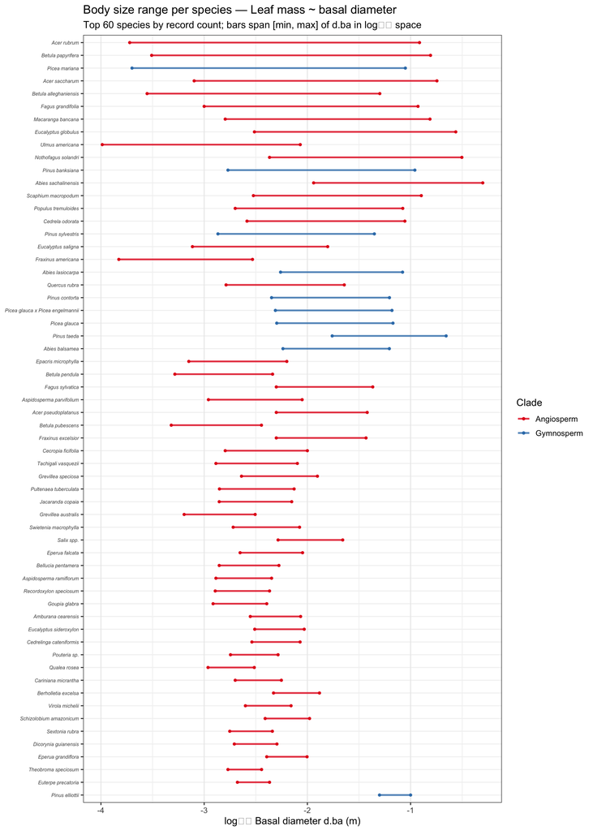

```r
plot_size_range(r1, co1)
```

## 2.3 Scaling slope vs. size range

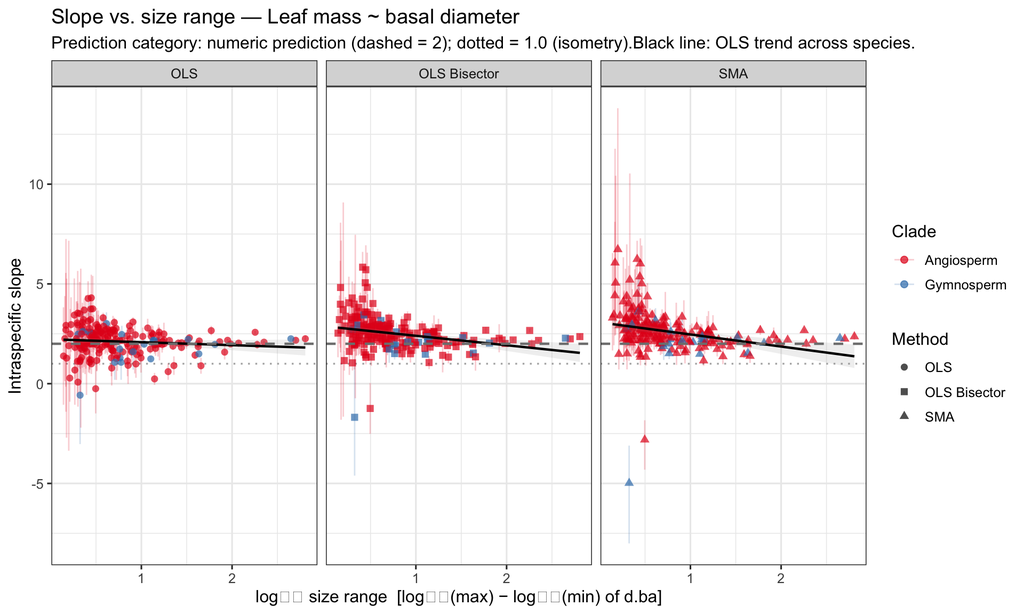

```r
plot_slope_vs_range(r1, co1)
```

## 2.4 Slope distributions

```r
slope_distribution_stats(
  r1,
  "Leaf mass ~ basal diameter: slope distribution summary statistics"
)
```

Leaf mass ~ basal diameter: slope distribution summary statistics

| Method | N | Mean slope | Median slope | Mean 95% CI lo | Mean 95% CI hi |
| --- | --- | --- | --- | --- | --- |
| OLS | 204 | 2.108 | 2.112 | 2.008 | 2.208 |
| SMA | 204 | 2.590 | 2.485 | 2.438 | 2.742 |
| OLS Bisector | 204 | 2.497 | 2.433 | 2.380 | 2.615 |

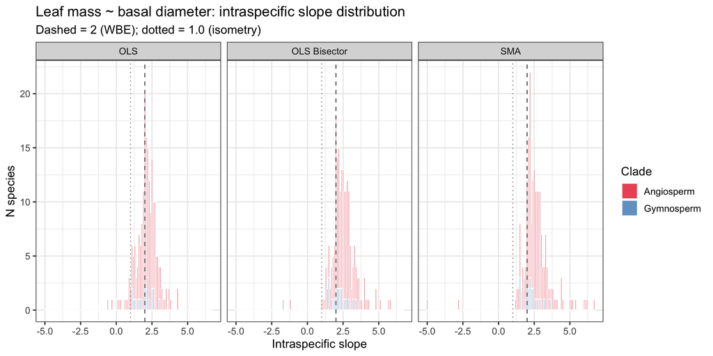

```r
if (nrow(r1) == 0) {
  ggplot() +
    theme_void() +
    labs(title = "Leaf mass ~ basal diameter: no qualifying species for slope distribution")
} else {
  r1_long <- r1 %>%
    pivot_longer(cols = c(ols_slope, sma_slope, bis_slope),
                 names_to = "method", values_to = "slope") %>%
    mutate(method = recode(method, ols_slope = "OLS", sma_slope = "SMA",
                           bis_slope = "OLS Bisector")) %>%
    filter(!is.na(slope), is.finite(slope))

  if (nrow(r1_long) == 0) {
    ggplot() +
      theme_void() +
      labs(title = "Leaf mass ~ basal diameter: no finite slope values available")
  } else {
    ggplot(r1_long, aes(x = slope, fill = clade)) +
      geom_histogram(binwidth = 0.1, colour = "white", alpha = 0.75, position = "stack") +
      geom_vline(xintercept = 2.00, linetype = "dashed", colour = "grey40") +
      geom_vline(xintercept = 1.00, linetype = "dotted", colour = "grey60") +
      facet_wrap(~ method) +
      scale_fill_manual(values = c(Angiosperm="#e41a1c", Gymnosperm="#377eb8"),
                        na.value="grey60", name="Clade") +
      labs(x = "Intraspecific slope", y = "N species",
           title = "Leaf mass ~ basal diameter: intraspecific slope distribution",
           subtitle = "Dashed = 2 (WBE); dotted = 1.0 (isometry)")
  }
}
```

# 3 Leaf area ~ Basal stem diameter (`a.lf ~ d.ba`)

```r
r2  <- results[["a.lf~d.ba"]]
co2 <- combos[[2]]
cat("Species qualifying (≥", MIN_N, "records):", nrow(r2), "\n")
```

```
## Species qualifying (≥ 10 records): 182
```

```r
cat("Median OLS slope:", round(median(r2$ols_slope, na.rm=TRUE), 3), "\n")
```

```
## Median OLS slope: 2.005
```

```r
cat("Median SMA slope:", round(median(r2$sma_slope, na.rm=TRUE), 3), "\n")
```

```
## Median SMA slope: 2.382
```

```r
cat("Median Bisector slope:", round(median(r2$bis_slope, na.rm=TRUE), 3), "\n")
```

```
## Median Bisector slope: 2.295
```

## 3.1 Per-species slopes table

```r
table_slopes(r2, paste0("Leaf area ~ basal diameter: per-species OLS, SMA, and OLS Bisector slopes (≥ ",
                         MIN_N, " records per species, sorted by N)"))
```

Leaf area ~ basal diameter: per-species OLS, SMA, and OLS Bisector slopes (≥ 10 records per species, sorted by N)

| Species | Family | Clade | N | OLS slope | OLS 95% lo | OLS 95% hi | SMA slope | SMA 95% lo | SMA 95% hi | Bisector slope | Bis 95% lo | Bis 95% hi | R² | log₁₀ size range |
| --- | --- | --- | --- | --- | --- | --- | --- | --- | --- | --- | --- | --- | --- | --- |
| *Betula alleghaniensis* | Betulaceae | Angiosperm | 366 | 2.499 | 2.423 | 2.576 | 2.607 | 2.532 | 2.685 | 2.606 | 2.510 | 2.702 | 0.919 | 2.254 |
| *Acer saccharum* | Aceraceae | Angiosperm | 329 | 1.930 | 1.844 | 2.017 | 2.088 | 2.003 | 2.176 | 2.084 | 2.000 | 2.168 | 0.855 | 1.778 |
| *Fagus grandifolia* | Fagaceae | Angiosperm | 229 | 1.838 | 1.728 | 1.948 | 2.021 | 1.914 | 2.134 | 2.015 | 1.900 | 2.131 | 0.827 | 2.072 |
| *Eucalyptus saligna* | Myrtaceae | Angiosperm | 216 | 2.166 | 2.094 | 2.237 | 2.230 | 2.160 | 2.303 | 2.230 | 2.159 | 2.300 | 0.943 | 1.310 |
| *Betula pendula* | Betulaceae | Angiosperm | 170 | 1.483 | 1.255 | 1.711 | 2.108 | 1.892 | 2.349 | 2.030 | 1.837 | 2.224 | 0.495 | 0.947 |
| *Betula pubescens* | Betulaceae | Angiosperm | 156 | 1.906 | 1.683 | 2.128 | 2.364 | 2.152 | 2.597 | 2.326 | 2.098 | 2.555 | 0.650 | 0.874 |
| *Pinus taeda* | Pinaceae | Gymnosperm | 129 | 2.820 | 2.538 | 3.101 | 3.243 | 2.974 | 3.536 | 3.217 | 2.934 | 3.499 | 0.756 | 0.835 |
| *Aspidosperma parvifolium* | Apocynaceae | Angiosperm | 118 | 2.506 | 2.249 | 2.763 | 2.870 | 2.624 | 3.139 | 2.850 | 2.462 | 3.237 | 0.762 | 0.908 |
| *Virola michelii* | Myristicaceae | Angiosperm | 118 | 3.800 | 3.107 | 4.493 | 5.351 | 4.703 | 6.088 | 5.073 | 4.256 | 5.889 | 0.504 | 0.442 |
| *Eperua falcata* | Caesalpiniaceae | Angiosperm | 115 | 2.296 | 1.934 | 2.657 | 3.006 | 2.666 | 3.390 | 2.922 | 2.512 | 3.331 | 0.583 | 0.605 |
| *Pouteria sp.* | Sapotaceae | Angiosperm | 114 | 2.367 | 1.675 | 3.060 | 4.392 | 3.753 | 5.139 | 3.745 | 3.080 | 4.411 | 0.291 | 0.461 |
| *Dicorynia guianensis* | Caesalpiniaceae | Angiosperm | 111 | 4.162 | 3.278 | 5.046 | 6.246 | 5.424 | 7.192 | 5.789 | 4.992 | 6.587 | 0.444 | 0.413 |
| *Recordoxylon speciosum* | Caesalpiniaceae | Angiosperm | 111 | 2.670 | 2.056 | 3.285 | 4.195 | 3.626 | 4.854 | 3.845 | 3.128 | 4.561 | 0.405 | 0.526 |
| *Eucalyptus sideroxylon* | Myrtaceae | Angiosperm | 107 | 1.684 | 1.392 | 1.975 | 2.258 | 1.986 | 2.568 | 2.195 | 1.872 | 2.519 | 0.556 | 0.479 |
| *Jacaranda copaia* | Bignoniaceae | Angiosperm | 101 | 2.817 | 2.582 | 3.052 | 3.054 | 2.828 | 3.298 | 3.046 | 2.795 | 3.296 | 0.851 | 0.702 |
| *Ulmus americana* | Ulmaceae | Angiosperm | 94 | 1.536 | 1.175 | 1.897 | 2.323 | 1.990 | 2.711 | 2.196 | 1.586 | 2.807 | 0.437 | 1.918 |
| *Nothofagus solandri* | Nothofagaceae | Angiosperm | 90 | 1.900 | 1.826 | 1.973 | 1.931 | 1.859 | 2.006 | 1.931 | 1.857 | 2.004 | 0.968 | 1.863 |
| *Eperua grandiflora* | Caesalpiniaceae | Angiosperm | 89 | 1.881 | 1.365 | 2.396 | 3.065 | 2.592 | 3.623 | 2.799 | 2.054 | 3.544 | 0.377 | 0.391 |
| *Goupia glabra* | Goupiaceae | Angiosperm | 88 | 2.784 | 2.480 | 3.089 | 3.125 | 2.836 | 3.444 | 3.108 | 2.767 | 3.450 | 0.794 | 0.520 |
| *Sextonia rubra* | Lauraceae | Angiosperm | 79 | 2.890 | 2.190 | 3.589 | 4.226 | 3.583 | 4.983 | 3.969 | 3.205 | 4.733 | 0.468 | 0.413 |
| *Theobroma speciosum* | Sterculiaceae | Angiosperm | 72 | 1.635 | 1.247 | 2.023 | 2.307 | 1.951 | 2.727 | 2.218 | 1.893 | 2.544 | 0.502 | 0.326 |
| *Acer rubrum* | Aceraceae | Angiosperm | 70 | 2.099 | 1.937 | 2.261 | 2.204 | 2.047 | 2.372 | 2.202 | 2.068 | 2.336 | 0.907 | 2.808 |
| *Cariniana micrantha* | Lecythidaceae | Angiosperm | 70 | 2.351 | 2.051 | 2.650 | 2.657 | 2.374 | 2.973 | 2.642 | 2.376 | 2.907 | 0.783 | 0.447 |
| *Aspidosperma ramiflorum* | Apocynaceae | Angiosperm | 69 | 2.115 | 1.856 | 2.374 | 2.368 | 2.122 | 2.641 | 2.357 | 2.082 | 2.632 | 0.798 | 0.539 |
| *Swietenia macrophylla* | Meliaceae | Angiosperm | 69 | 2.216 | 1.806 | 2.625 | 2.779 | 2.400 | 3.219 | 2.726 | 2.366 | 3.085 | 0.635 | 0.643 |
| *Tachigali vasquezii* | Fabaceae | Angiosperm | 69 | 1.952 | 1.657 | 2.248 | 2.298 | 2.021 | 2.613 | 2.278 | 1.926 | 2.629 | 0.722 | 0.789 |
| *Cedrela odorata* | Meliaceae | Angiosperm | 67 | 1.753 | 1.524 | 1.982 | 1.982 | 1.766 | 2.224 | 1.973 | 1.761 | 2.184 | 0.783 | 1.530 |
| *Eucalyptus globulus* | Myrtaceae | Angiosperm | 65 | 2.024 | 1.928 | 2.121 | 2.060 | 1.966 | 2.159 | 2.060 | 1.939 | 2.182 | 0.965 | 1.951 |
| *Pinus sylvestris* | Pinaceae | Gymnosperm | 65 | 2.034 | 1.884 | 2.184 | 2.119 | 1.975 | 2.274 | 2.118 | 1.993 | 2.243 | 0.921 | 1.515 |
| *Fraxinus americana* | Oleaceae | Angiosperm | 64 | 0.092 | -0.273 | 0.458 | 1.442 | 1.122 | 1.853 | 1.049 | 0.762 | 1.335 | 0.004 | 1.295 |

[output cut: 152 more lines]

## 3.2 Body size range per species

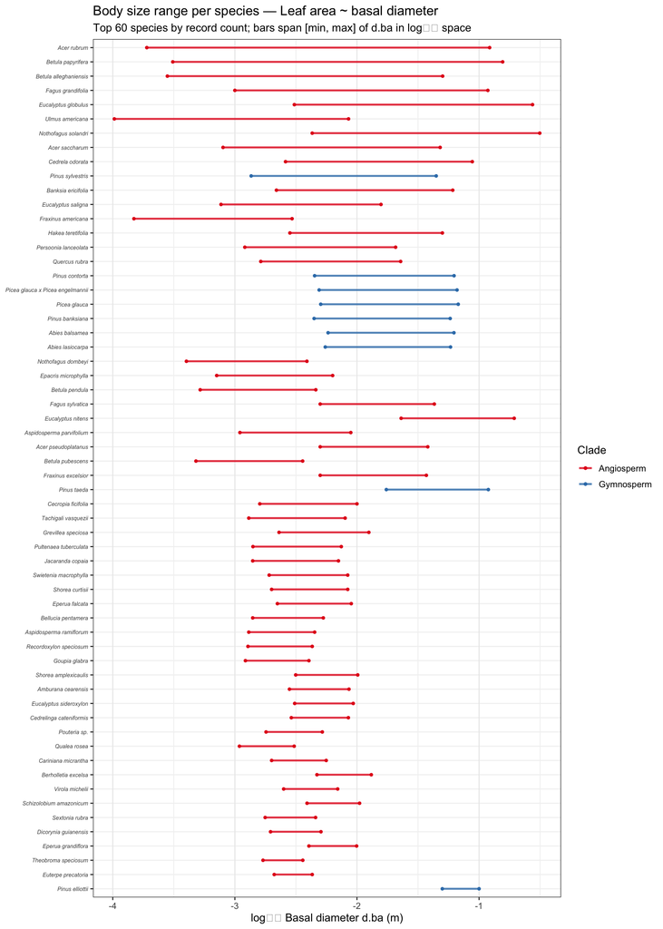

```r
plot_size_range(r2, co2)
```

## 3.3 Scaling slope vs. size range

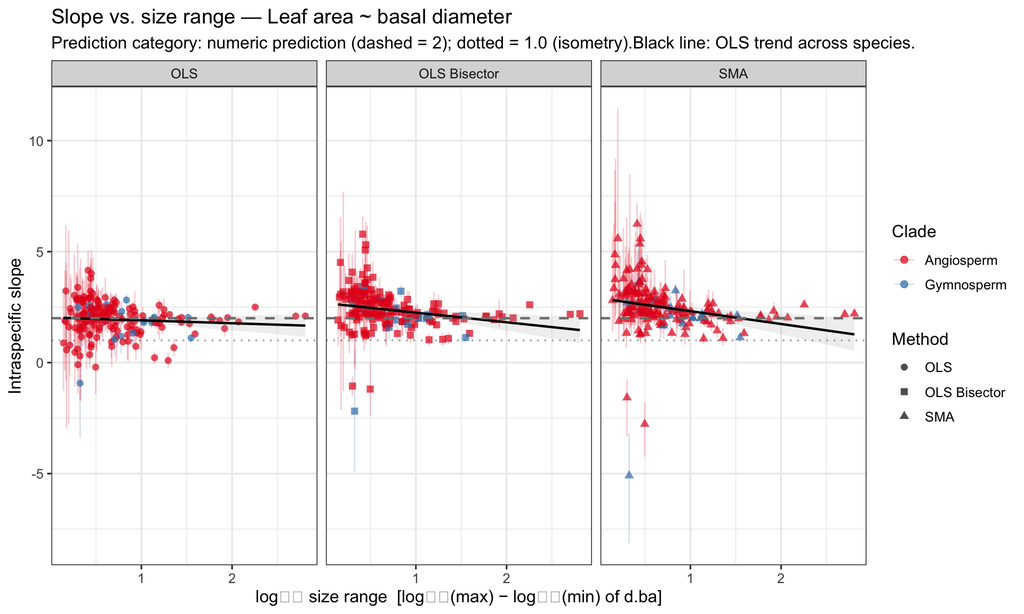

```r
plot_slope_vs_range(r2, co2)
```

## 3.4 Slope distributions

```r
slope_distribution_stats(
  r2,
  "Leaf area ~ basal diameter: slope distribution summary statistics"
)
```

Leaf area ~ basal diameter: slope distribution summary statistics

| Method | N | Mean slope | Median slope | Mean 95% CI lo | Mean 95% CI hi |
| --- | --- | --- | --- | --- | --- |
| OLS | 182 | 1.941 | 2.005 | 1.831 | 2.050 |
| SMA | 182 | 2.480 | 2.382 | 2.316 | 2.645 |
| OLS Bisector | 182 | 2.371 | 2.295 | 2.239 | 2.503 |

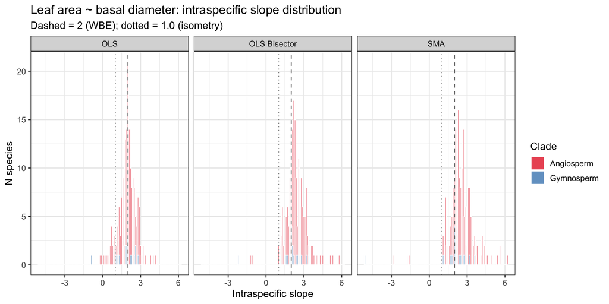

```r
if (nrow(r2) == 0) {
  ggplot() +
    theme_void() +
    labs(title = "Leaf area ~ basal diameter: no qualifying species for slope distribution")
} else {
  r2_long <- r2 %>%
    pivot_longer(cols = c(ols_slope, sma_slope, bis_slope),
                 names_to = "method", values_to = "slope") %>%
    mutate(method = recode(method, ols_slope = "OLS", sma_slope = "SMA",
                           bis_slope = "OLS Bisector")) %>%
    filter(!is.na(slope), is.finite(slope))

  if (nrow(r2_long) == 0) {
    ggplot() +
      theme_void() +
      labs(title = "Leaf area ~ basal diameter: no finite slope values available")
  } else {
    ggplot(r2_long, aes(x = slope, fill = clade)) +
      geom_histogram(binwidth = 0.1, colour = "white", alpha = 0.75, position = "stack") +
      geom_vline(xintercept = 2.00, linetype = "dashed", colour = "grey40") +
      geom_vline(xintercept = 1.00, linetype = "dotted", colour = "grey60") +
      facet_wrap(~ method) +
      scale_fill_manual(values = c(Angiosperm="#e41a1c", Gymnosperm="#377eb8"),
                        na.value="grey60", name="Clade") +
      labs(x = "Intraspecific slope", y = "N species",
           title = "Leaf area ~ basal diameter: intraspecific slope distribution",
           subtitle = "Dashed = 2 (WBE); dotted = 1.0 (isometry)")
  }
}
```

# 4 Leaf mass ~ Total plant biomass (`m.lf ~ m.to`)

```r
r3  <- results[["m.lf~m.to"]]
co3 <- combos[[3]]
cat("Species qualifying (≥", MIN_N, "records):", nrow(r3), "\n")
```

```
## Species qualifying (≥ 10 records): 171
```

```r
cat("Median OLS slope:", round(median(r3$ols_slope, na.rm=TRUE), 3), "\n")
```

```
## Median OLS slope: 0.959
```

```r
cat("Median SMA slope:", round(median(r3$sma_slope, na.rm=TRUE), 3), "\n")
```

```
## Median SMA slope: 1.007
```

```r
cat("Median Bisector slope:", round(median(r3$bis_slope, na.rm=TRUE), 3), "\n")
```

```
## Median Bisector slope: 1.007
```

## 4.1 Per-species slopes table

```r
table_slopes(r3, paste0("Leaf mass ~ total biomass: per-species OLS, SMA, and OLS Bisector slopes (≥ ",
                         MIN_N, " records per species, sorted by N)"))
```

Leaf mass ~ total biomass: per-species OLS, SMA, and OLS Bisector slopes (≥ 10 records per species, sorted by N)

| Species | Family | Clade | N | OLS slope | OLS 95% lo | OLS 95% hi | SMA slope | SMA 95% lo | SMA 95% hi | Bisector slope | Bis 95% lo | Bis 95% hi | R² | log₁₀ size range |
| --- | --- | --- | --- | --- | --- | --- | --- | --- | --- | --- | --- | --- | --- | --- |
| *Betula alleghaniensis* | Betulaceae | Angiosperm | 415 | 0.866 | 0.853 | 0.880 | 0.878 | 0.864 | 0.891 | 0.878 | 0.857 | 0.898 | 0.974 | 9.366 |
| *Acer saccharum* | Aceraceae | Angiosperm | 371 | 0.798 | 0.785 | 0.810 | 0.807 | 0.795 | 0.820 | 0.807 | 0.797 | 0.818 | 0.976 | 8.377 |
| *Eucalyptus saligna* | Myrtaceae | Angiosperm | 276 | 0.997 | 0.974 | 1.019 | 1.015 | 0.992 | 1.038 | 1.015 | 0.981 | 1.048 | 0.965 | 2.544 |
| *Fagus grandifolia* | Fagaceae | Angiosperm | 240 | 0.788 | 0.774 | 0.801 | 0.794 | 0.781 | 0.808 | 0.794 | 0.780 | 0.809 | 0.983 | 7.248 |
| *Eucalyptus sideroxylon* | Myrtaceae | Angiosperm | 203 | 0.886 | 0.863 | 0.909 | 0.901 | 0.878 | 0.924 | 0.901 | 0.878 | 0.923 | 0.968 | 2.303 |
| *Juglans major* | Juglandaceae | Angiosperm | 184 | 0.711 | 0.441 | 0.981 | 1.976 | 1.725 | 2.264 | 1.572 | 1.309 | 1.836 | 0.129 | 1.200 |
| *Persea hintonii* | Lauraceae | Angiosperm | 182 | 1.230 | 1.074 | 1.386 | 1.624 | 1.476 | 1.788 | 1.597 | 1.461 | 1.733 | 0.574 | 2.055 |
| *Magnolia iltisiana* | Magnoliaceae | Angiosperm | 171 | 0.864 | 0.648 | 1.080 | 1.663 | 1.461 | 1.893 | 1.525 | 1.377 | 1.672 | 0.270 | 1.542 |
| *Betula pendula* | Betulaceae | Angiosperm | 170 | 0.921 | 0.859 | 0.984 | 1.008 | 0.948 | 1.072 | 1.008 | 0.933 | 1.083 | 0.835 | 2.085 |
| *Citharexylum mocinnii* | Verbenaceae | Angiosperm | 164 | 1.002 | 0.878 | 1.127 | 1.284 | 1.165 | 1.414 | 1.274 | 1.184 | 1.365 | 0.609 | 2.802 |
| *Pinus sylvestris* | Pinaceae | Gymnosperm | 158 | 0.814 | 0.792 | 0.836 | 0.826 | 0.804 | 0.849 | 0.826 | 0.803 | 0.849 | 0.971 | 6.632 |
| *Betula pubescens* | Betulaceae | Angiosperm | 156 | 1.037 | 0.999 | 1.076 | 1.066 | 1.028 | 1.105 | 1.066 | 1.021 | 1.110 | 0.948 | 1.818 |
| *Dendropanax arboreus* | Araliaceae | Angiosperm | 150 | 0.675 | 0.567 | 0.784 | 0.948 | 0.846 | 1.063 | 0.951 | 0.873 | 1.030 | 0.507 | 2.372 |
| *Fraxinus uhdei* | Oleaceae | Angiosperm | 142 | 1.051 | 0.964 | 1.137 | 1.171 | 1.088 | 1.260 | 1.170 | 1.098 | 1.241 | 0.805 | 2.612 |
| *Theobroma speciosum* | Sterculiaceae | Angiosperm | 119 | 1.461 | 1.428 | 1.494 | 1.472 | 1.439 | 1.506 | 1.472 | 1.433 | 1.512 | 0.985 | 1.822 |
| *Ulmus americana* | Ulmaceae | Angiosperm | 119 | 1.001 | 0.916 | 1.086 | 1.104 | 1.022 | 1.192 | 1.103 | 1.007 | 1.200 | 0.823 | 3.195 |
| *Aspidosperma parvifolium* | Apocynaceae | Angiosperm | 118 | 1.201 | 1.120 | 1.283 | 1.280 | 1.202 | 1.365 | 1.280 | 1.165 | 1.394 | 0.880 | 2.368 |
| *Virola michelii* | Myristicaceae | Angiosperm | 118 | 1.399 | 1.295 | 1.502 | 1.508 | 1.408 | 1.615 | 1.506 | 1.308 | 1.704 | 0.861 | 1.363 |
| *Cariniana micrantha* | Lecythidaceae | Angiosperm | 117 | 1.009 | 0.990 | 1.028 | 1.014 | 0.995 | 1.033 | 1.014 | 0.996 | 1.031 | 0.990 | 2.069 |
| *Tachigali vasquezii* | Fabaceae | Angiosperm | 117 | 0.999 | 0.981 | 1.018 | 1.004 | 0.986 | 1.022 | 1.004 | 0.993 | 1.016 | 0.990 | 2.187 |
| *Cedrela odorata* | Meliaceae | Angiosperm | 115 | 0.893 | 0.869 | 0.918 | 0.903 | 0.879 | 0.927 | 0.903 | 0.867 | 0.938 | 0.979 | 5.241 |
| *Eperua falcata* | Caesalpiniaceae | Angiosperm | 115 | 1.152 | 1.063 | 1.240 | 1.246 | 1.160 | 1.337 | 1.245 | 1.170 | 1.320 | 0.855 | 1.149 |
| *Pouteria sp.* | Sapotaceae | Angiosperm | 115 | 1.090 | 0.922 | 1.259 | 1.416 | 1.257 | 1.594 | 1.400 | 1.172 | 1.628 | 0.593 | 1.287 |
| *Euterpe precatoria* | Aracaceae | Angiosperm | 113 | 0.990 | 0.955 | 1.025 | 1.007 | 0.973 | 1.042 | 1.007 | 0.971 | 1.043 | 0.966 | 1.695 |
| *Swietenia macrophylla* | Meliaceae | Angiosperm | 113 | 0.933 | 0.913 | 0.954 | 0.940 | 0.919 | 0.961 | 0.940 | 0.922 | 0.958 | 0.986 | 1.807 |
| *Dicorynia guianensis* | Caesalpiniaceae | Angiosperm | 111 | 1.535 | 1.434 | 1.637 | 1.626 | 1.527 | 1.731 | 1.625 | 1.478 | 1.771 | 0.892 | 1.359 |
| *Recordoxylon speciosum* | Caesalpiniaceae | Angiosperm | 111 | 1.397 | 1.243 | 1.550 | 1.614 | 1.468 | 1.775 | 1.607 | 1.245 | 1.968 | 0.749 | 1.239 |
| *Bellucia pentamera* | Melastomataceae | Angiosperm | 108 | 0.967 | 0.954 | 0.981 | 0.970 | 0.957 | 0.983 | 0.970 | 0.958 | 0.982 | 0.995 | 2.653 |
| *Cecropia ficifolia* | Cecropiaceae | Angiosperm | 107 | 1.002 | 0.945 | 1.059 | 1.045 | 0.989 | 1.103 | 1.045 | 0.983 | 1.106 | 0.920 | 2.329 |
| *Amburana cearensis* | Fabaceae | Angiosperm | 106 | 0.785 | 0.742 | 0.828 | 0.815 | 0.773 | 0.859 | 0.815 | 0.780 | 0.851 | 0.927 | 1.936 |

[output cut: 141 more lines]

## 4.2 Body size range per species

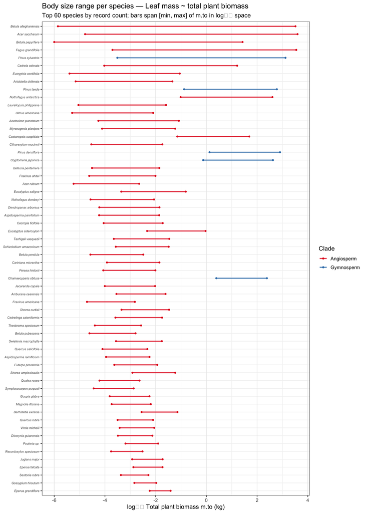

```r
plot_size_range(r3, co3)
```

## 4.3 Scaling slope vs. size range

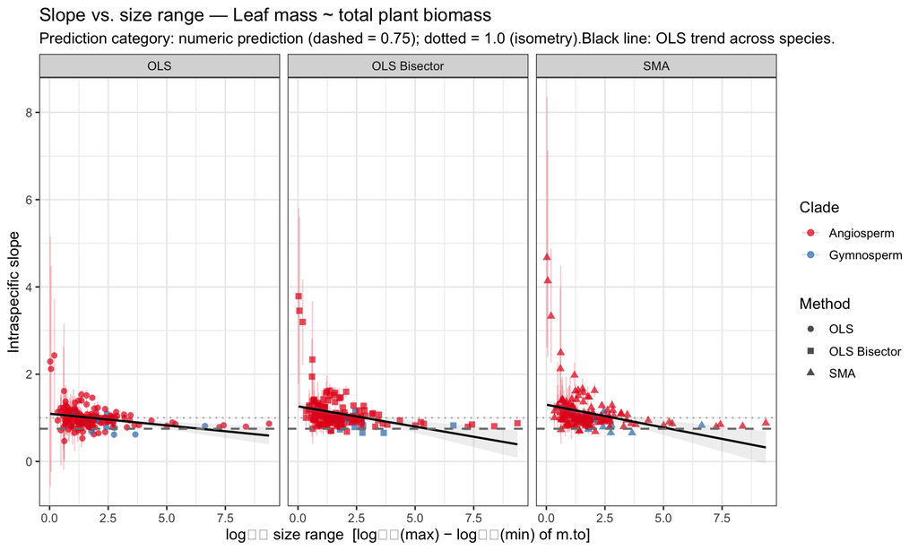

```r
plot_slope_vs_range(r3, co3)
```

## 4.4 Slope distributions

```r
slope_distribution_stats(
  r3,
  "Leaf mass ~ total plant biomass: slope distribution summary statistics"
)
```

Leaf mass ~ total plant biomass: slope distribution summary statistics

| Method | N | Mean slope | Median slope | Mean 95% CI lo | Mean 95% CI hi |
| --- | --- | --- | --- | --- | --- |
| OLS | 171 | 0.995 | 0.959 | 0.957 | 1.033 |
| SMA | 171 | 1.108 | 1.007 | 1.037 | 1.180 |
| OLS Bisector | 171 | 1.092 | 1.007 | 1.032 | 1.152 |

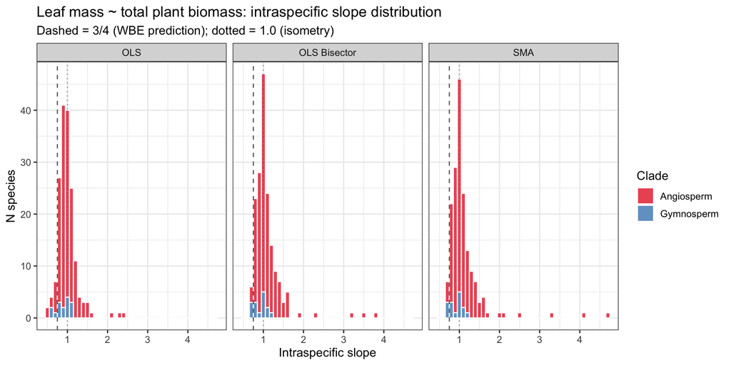

```r
if (nrow(r3) == 0) {
  ggplot() +
    theme_void() +
    labs(title = "Leaf mass ~ total plant biomass: no qualifying species for slope distribution")
} else {
  r3_long <- r3 %>%
    pivot_longer(cols = c(ols_slope, sma_slope, bis_slope),
                 names_to = "method", values_to = "slope") %>%
    mutate(method = recode(method, ols_slope = "OLS", sma_slope = "SMA",
                           bis_slope = "OLS Bisector")) %>%
    filter(!is.na(slope), is.finite(slope))

  if (nrow(r3_long) == 0) {
    ggplot() +
      theme_void() +
      labs(title = "Leaf mass ~ total plant biomass: no finite slope values available")
  } else {
    ggplot(r3_long, aes(x = slope, fill = clade)) +
      geom_histogram(binwidth = 0.1, colour = "white", alpha = 0.75, position = "stack") +
      geom_vline(xintercept = 0.75, linetype = "dashed", colour = "grey40") +
      geom_vline(xintercept = 1.00, linetype = "dotted", colour = "grey60") +
      facet_wrap(~ method) +
      scale_fill_manual(values = c(Angiosperm="#e41a1c", Gymnosperm="#377eb8"),
                        na.value="grey60", name="Clade") +
      labs(x = "Intraspecific slope", y = "N species",
           title = "Leaf mass ~ total plant biomass: intraspecific slope distribution",
           subtitle = "Dashed = 3/4 (WBE prediction); dotted = 1.0 (isometry)")
  }
}
```

# 5 Leaf area ~ Total plant biomass (`a.lf ~ m.to`)

```r
r4  <- results[["a.lf~m.to"]]
co4 <- combos[[4]]
cat("Species qualifying (≥", MIN_N, "records):", nrow(r4), "\n")
```

```
## Species qualifying (≥ 10 records): 156
```

```r
cat("Median OLS slope:", round(median(r4$ols_slope, na.rm=TRUE), 3), "\n")
```

```
## Median OLS slope: 0.881
```

```r
cat("Median SMA slope:", round(median(r4$sma_slope, na.rm=TRUE), 3), "\n")
```

```
## Median SMA slope: 0.947
```

```r
cat("Median Bisector slope:", round(median(r4$bis_slope, na.rm=TRUE), 3), "\n")
```

```
## Median Bisector slope: 0.948
```

## 5.1 Per-species slopes table

```r
table_slopes(r4, paste0("Leaf area ~ total biomass: per-species OLS, SMA, and OLS Bisector slopes (≥ ",
                         MIN_N, " records per species, sorted by N)"))
```

Leaf area ~ total biomass: per-species OLS, SMA, and OLS Bisector slopes (≥ 10 records per species, sorted by N)

| Species | Family | Clade | N | OLS slope | OLS 95% lo | OLS 95% hi | SMA slope | SMA 95% lo | SMA 95% hi | Bisector slope | Bis 95% lo | Bis 95% hi | R² | log₁₀ size range |
| --- | --- | --- | --- | --- | --- | --- | --- | --- | --- | --- | --- | --- | --- | --- |
| *Betula alleghaniensis* | Betulaceae | Angiosperm | 391 | 0.882 | 0.865 | 0.898 | 0.898 | 0.881 | 0.915 | 0.898 | 0.878 | 0.917 | 0.965 | 6.037 |
| *Acer saccharum* | Aceraceae | Angiosperm | 347 | 0.793 | 0.770 | 0.816 | 0.823 | 0.800 | 0.846 | 0.823 | 0.804 | 0.842 | 0.929 | 4.730 |
| *Eucalyptus saligna* | Myrtaceae | Angiosperm | 276 | 0.966 | 0.931 | 1.001 | 1.010 | 0.975 | 1.046 | 1.010 | 0.964 | 1.056 | 0.914 | 2.544 |
| *Fagus grandifolia* | Fagaceae | Angiosperm | 219 | 0.710 | 0.643 | 0.776 | 0.867 | 0.803 | 0.936 | 0.869 | 0.796 | 0.942 | 0.671 | 1.908 |
| *Eucalyptus sideroxylon* | Myrtaceae | Angiosperm | 184 | 0.777 | 0.739 | 0.815 | 0.819 | 0.782 | 0.857 | 0.819 | 0.777 | 0.861 | 0.901 | 2.303 |
| *Juglans major* | Juglandaceae | Angiosperm | 184 | 0.466 | 0.186 | 0.746 | 1.970 | 1.710 | 2.270 | 1.380 | 1.104 | 1.656 | 0.056 | 1.200 |
| *Persea hintonii* | Lauraceae | Angiosperm | 182 | 1.296 | 1.124 | 1.468 | 1.746 | 1.582 | 1.927 | 1.708 | 1.556 | 1.860 | 0.551 | 2.055 |
| *Magnolia iltisiana* | Magnoliaceae | Angiosperm | 171 | 0.853 | 0.626 | 1.080 | 1.721 | 1.509 | 1.963 | 1.552 | 1.392 | 1.711 | 0.246 | 1.542 |
| *Betula pendula* | Betulaceae | Angiosperm | 170 | 0.766 | 0.681 | 0.851 | 0.947 | 0.866 | 1.035 | 0.948 | 0.861 | 1.035 | 0.655 | 2.085 |
| *Citharexylum mocinnii* | Verbenaceae | Angiosperm | 164 | 0.998 | 0.855 | 1.141 | 1.359 | 1.223 | 1.509 | 1.340 | 1.226 | 1.455 | 0.540 | 2.802 |
| *Betula pubescens* | Betulaceae | Angiosperm | 156 | 0.885 | 0.828 | 0.943 | 0.956 | 0.900 | 1.015 | 0.956 | 0.892 | 1.021 | 0.857 | 1.818 |
| *Dendropanax arboreus* | Araliaceae | Angiosperm | 150 | 0.613 | 0.502 | 0.724 | 0.917 | 0.813 | 1.035 | 0.923 | 0.847 | 1.000 | 0.447 | 2.372 |
| *Fraxinus uhdei* | Oleaceae | Angiosperm | 142 | 0.989 | 0.877 | 1.101 | 1.194 | 1.087 | 1.311 | 1.190 | 1.098 | 1.283 | 0.686 | 2.612 |
| *Theobroma speciosum* | Sterculiaceae | Angiosperm | 119 | 1.348 | 1.304 | 1.393 | 1.370 | 1.326 | 1.415 | 1.370 | 1.322 | 1.418 | 0.968 | 1.822 |
| *Aspidosperma parvifolium* | Apocynaceae | Angiosperm | 118 | 0.968 | 0.873 | 1.063 | 1.097 | 1.006 | 1.196 | 1.097 | 0.936 | 1.257 | 0.778 | 2.368 |
| *Virola michelii* | Myristicaceae | Angiosperm | 118 | 1.398 | 1.296 | 1.500 | 1.503 | 1.405 | 1.609 | 1.502 | 1.348 | 1.656 | 0.865 | 1.363 |
| *Cariniana micrantha* | Lecythidaceae | Angiosperm | 117 | 0.985 | 0.956 | 1.015 | 0.999 | 0.969 | 1.029 | 0.999 | 0.974 | 1.023 | 0.974 | 2.069 |
| *Tachigali vasquezii* | Fabaceae | Angiosperm | 117 | 0.882 | 0.843 | 0.921 | 0.907 | 0.869 | 0.947 | 0.907 | 0.880 | 0.935 | 0.946 | 2.187 |
| *Eperua falcata* | Caesalpiniaceae | Angiosperm | 115 | 1.166 | 1.066 | 1.265 | 1.282 | 1.187 | 1.386 | 1.281 | 1.207 | 1.354 | 0.826 | 1.149 |
| *Cedrela odorata* | Meliaceae | Angiosperm | 114 | 0.738 | 0.697 | 0.780 | 0.771 | 0.730 | 0.813 | 0.771 | 0.715 | 0.827 | 0.918 | 5.241 |
| *Pouteria sp.* | Sapotaceae | Angiosperm | 114 | 1.068 | 0.851 | 1.285 | 1.577 | 1.375 | 1.809 | 1.529 | 1.272 | 1.786 | 0.459 | 1.287 |
| *Ulmus americana* | Ulmaceae | Angiosperm | 114 | 0.820 | 0.727 | 0.913 | 0.959 | 0.870 | 1.056 | 0.959 | 0.875 | 1.044 | 0.732 | 3.195 |
| *Euterpe precatoria* | Aracaceae | Angiosperm | 113 | 0.911 | 0.854 | 0.968 | 0.960 | 0.905 | 1.018 | 0.960 | 0.908 | 1.012 | 0.901 | 1.695 |
| *Swietenia macrophylla* | Meliaceae | Angiosperm | 113 | 0.796 | 0.745 | 0.846 | 0.840 | 0.791 | 0.891 | 0.840 | 0.795 | 0.884 | 0.898 | 1.807 |
| *Dicorynia guianensis* | Caesalpiniaceae | Angiosperm | 111 | 1.519 | 1.408 | 1.630 | 1.627 | 1.520 | 1.742 | 1.625 | 1.466 | 1.785 | 0.872 | 1.359 |
| *Recordoxylon speciosum* | Caesalpiniaceae | Angiosperm | 111 | 1.329 | 1.177 | 1.481 | 1.552 | 1.407 | 1.711 | 1.544 | 1.222 | 1.866 | 0.734 | 1.239 |
| *Bellucia pentamera* | Melastomataceae | Angiosperm | 108 | 0.799 | 0.750 | 0.847 | 0.838 | 0.790 | 0.888 | 0.838 | 0.798 | 0.877 | 0.909 | 2.653 |
| *Cecropia ficifolia* | Cecropiaceae | Angiosperm | 107 | 0.880 | 0.783 | 0.977 | 1.012 | 0.920 | 1.113 | 1.012 | 0.927 | 1.096 | 0.756 | 2.329 |
| *Schizolobium amazonicum* | Fabaceae | Angiosperm | 106 | 0.509 | 0.451 | 0.568 | 0.591 | 0.536 | 0.652 | 0.594 | 0.536 | 0.653 | 0.742 | 2.086 |
| *Amburana cearensis* | Fabaceae | Angiosperm | 105 | 0.664 | 0.593 | 0.734 | 0.755 | 0.688 | 0.828 | 0.757 | 0.692 | 0.821 | 0.773 | 1.936 |

[output cut: 126 more lines]

## 5.2 Body size range per species

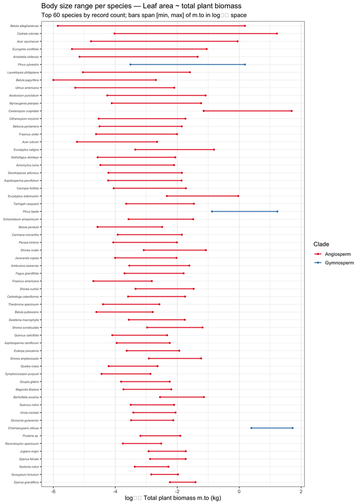

```r
plot_size_range(r4, co4)
```

## 5.3 Scaling slope vs. size range

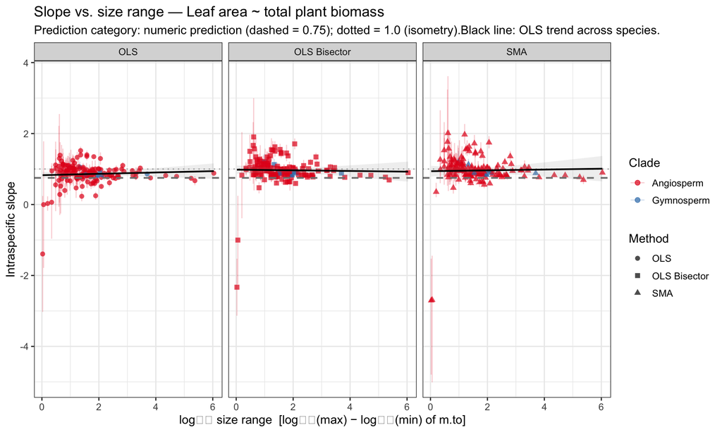

```r
plot_slope_vs_range(r4, co4)
```

## 5.4 Slope distributions

```r
slope_distribution_stats(
  r4,
  "Leaf area ~ total plant biomass: slope distribution summary statistics"
)
```

Leaf area ~ total plant biomass: slope distribution summary statistics

| Method | N | Mean slope | Median slope | Mean 95% CI lo | Mean 95% CI hi |
| --- | --- | --- | --- | --- | --- |
| OLS | 156 | 0.858 | 0.881 | 0.810 | 0.906 |
| SMA | 156 | 0.958 | 0.947 | 0.879 | 1.036 |
| OLS Bisector | 156 | 0.967 | 0.948 | 0.905 | 1.028 |

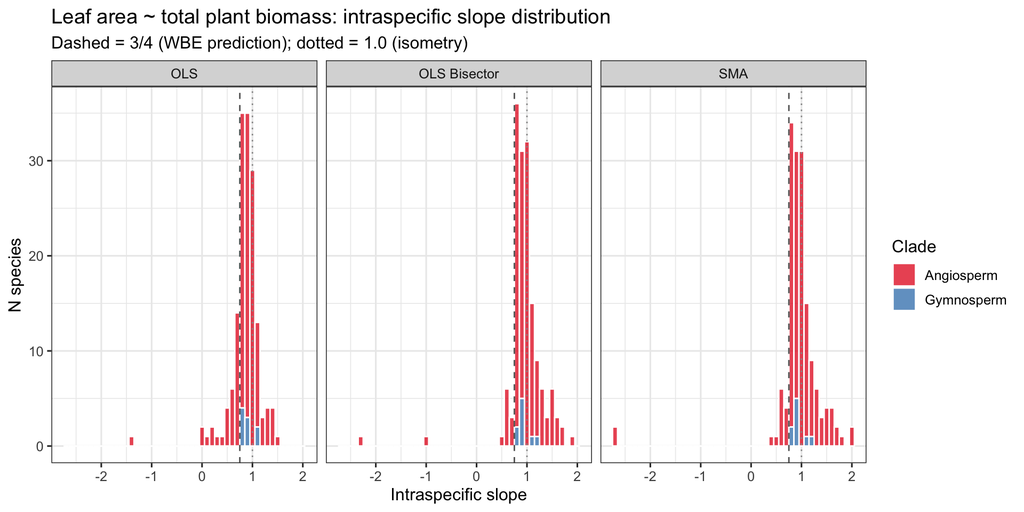

```r
if (nrow(r4) == 0) {
  ggplot() +
    theme_void() +
    labs(title = "Leaf area ~ total plant biomass: no qualifying species for slope distribution")
} else {
  r4_long <- r4 %>%
    pivot_longer(cols = c(ols_slope, sma_slope, bis_slope),
                 names_to = "method", values_to = "slope") %>%
    mutate(method = recode(method, ols_slope = "OLS", sma_slope = "SMA",
                           bis_slope = "OLS Bisector")) %>%
    filter(!is.na(slope), is.finite(slope))

  if (nrow(r4_long) == 0) {
    ggplot() +
      theme_void() +
      labs(title = "Leaf area ~ total plant biomass: no finite slope values available")
  } else {
    ggplot(r4_long, aes(x = slope, fill = clade)) +
      geom_histogram(binwidth = 0.1, colour = "white", alpha = 0.75, position = "stack") +
      geom_vline(xintercept = 0.75, linetype = "dashed", colour = "grey40") +
      geom_vline(xintercept = 1.00, linetype = "dotted", colour = "grey60") +
      facet_wrap(~ method) +
      scale_fill_manual(values = c(Angiosperm="#e41a1c", Gymnosperm="#377eb8"),
                        na.value="grey60", name="Clade") +
      labs(x = "Intraspecific slope", y = "N species",
           title = "Leaf area ~ total plant biomass: intraspecific slope distribution",
           subtitle = "Dashed = 3/4 (WBE prediction); dotted = 1.0 (isometry)")
  }
}
```

# 6 Leaf mass ~ Stem mass (`m.lf ~ m.st`)

```r
r5  <- results[["m.lf~m.st"]]
co5 <- combos[[5]]
cat("Species qualifying (≥", MIN_N, "records):", nrow(r5), "\n")
```

```
## Species qualifying (≥ 10 records): 288
```

```r
cat("Median OLS slope:", round(median(r5$ols_slope, na.rm=TRUE), 3), "\n")
```

```
## Median OLS slope: 0.776
```

```r
cat("Median SMA slope:", round(median(r5$sma_slope, na.rm=TRUE), 3), "\n")
```

```
## Median SMA slope: 0.884
```

```r
cat("Median Bisector slope:", round(median(r5$bis_slope, na.rm=TRUE), 3), "\n")
```

```
## Median Bisector slope: 0.886
```

## 6.1 Per-species slopes table

```r
table_slopes(r5, paste0("Leaf mass ~ stem mass: per-species OLS, SMA, and OLS Bisector slopes (≥ ",
                         MIN_N, " records per species, sorted by N)"))
```

Leaf mass ~ stem mass: per-species OLS, SMA, and OLS Bisector slopes (≥ 10 records per species, sorted by N)

| Species | Family | Clade | N | OLS slope | OLS 95% lo | OLS 95% hi | SMA slope | SMA 95% lo | SMA 95% hi | Bisector slope | Bis 95% lo | Bis 95% hi | R² | log₁₀ size range |
| --- | --- | --- | --- | --- | --- | --- | --- | --- | --- | --- | --- | --- | --- | --- |
| *Betula alleghaniensis* | Betulaceae | Angiosperm | 415 | 0.802 | 0.786 | 0.819 | 0.820 | 0.804 | 0.837 | 0.820 | 0.797 | 0.844 | 0.957 | 9.750 |
| *Acer saccharum* | Aceraceae | Angiosperm | 371 | 0.725 | 0.710 | 0.740 | 0.739 | 0.724 | 0.754 | 0.739 | 0.728 | 0.750 | 0.961 | 8.782 |
| *Pinus sylvestris* | Pinaceae | Gymnosperm | 356 | 0.726 | 0.703 | 0.749 | 0.757 | 0.735 | 0.780 | 0.758 | 0.737 | 0.778 | 0.919 | 7.348 |
| *Pinus taeda* | Pinaceae | Gymnosperm | 318 | 0.435 | 0.409 | 0.462 | 0.496 | 0.470 | 0.523 | 0.498 | 0.473 | 0.524 | 0.771 | 4.217 |
| *Eucalyptus saligna* | Myrtaceae | Angiosperm | 276 | 0.803 | 0.789 | 0.817 | 0.811 | 0.798 | 0.825 | 0.811 | 0.793 | 0.829 | 0.980 | 3.192 |
| *Fagus grandifolia* | Fagaceae | Angiosperm | 243 | 0.736 | 0.718 | 0.754 | 0.750 | 0.732 | 0.768 | 0.750 | 0.735 | 0.764 | 0.965 | 7.869 |
| *Eucalyptus sideroxylon* | Myrtaceae | Angiosperm | 203 | 0.788 | 0.757 | 0.819 | 0.819 | 0.789 | 0.851 | 0.819 | 0.788 | 0.851 | 0.926 | 2.745 |
| *Betula pendula* | Betulaceae | Angiosperm | 200 | 0.691 | 0.674 | 0.708 | 0.702 | 0.685 | 0.719 | 0.702 | 0.680 | 0.723 | 0.970 | 8.036 |
| *Cryptomeria japonica* | Taxodiaceae | Gymnosperm | 189 | 0.633 | 0.593 | 0.672 | 0.689 | 0.651 | 0.730 | 0.690 | 0.641 | 0.740 | 0.842 | 4.041 |
| *Juglans major* | Juglandaceae | Angiosperm | 184 | 0.228 | 0.010 | 0.447 | 1.513 | 1.310 | 1.748 | 1.134 | 0.992 | 1.275 | 0.023 | 1.859 |
| *Persea hintonii* | Lauraceae | Angiosperm | 182 | 0.039 | -0.151 | 0.229 | 1.295 | 1.118 | 1.499 | 1.016 | 0.918 | 1.114 | 0.001 | 1.854 |
| *Magnolia iltisiana* | Magnoliaceae | Angiosperm | 171 | -0.083 | -0.240 | 0.074 | -1.036 | -1.205 | -0.891 | -1.006 | -1.033 | -0.979 | 0.006 | 2.500 |
| *Cecropia ficifolia* | Cecropiaceae | Angiosperm | 169 | 0.713 | 0.672 | 0.754 | 0.762 | 0.722 | 0.805 | 0.763 | 0.712 | 0.813 | 0.875 | 4.867 |
| *Toxicodendron trichocarpum* | Anacardiaceae | Angiosperm | 167 | 0.697 | 0.640 | 0.755 | 0.790 | 0.735 | 0.849 | 0.792 | 0.724 | 0.859 | 0.779 | 3.334 |
| *Citharexylum mocinnii* | Verbenaceae | Angiosperm | 164 | 0.282 | 0.138 | 0.426 | 0.972 | 0.838 | 1.127 | 0.985 | 0.931 | 1.039 | 0.084 | 3.132 |
| *Betula papyrifera* | Betulaceae | Angiosperm | 156 | 0.748 | 0.723 | 0.773 | 0.765 | 0.740 | 0.790 | 0.765 | 0.738 | 0.791 | 0.958 | 9.817 |
| *Betula pubescens* | Betulaceae | Angiosperm | 156 | 0.998 | 0.932 | 1.064 | 1.081 | 1.017 | 1.149 | 1.081 | 1.017 | 1.145 | 0.852 | 2.064 |
| *Pinus densiflora* | Pinaceae | Gymnosperm | 153 | 0.805 | 0.764 | 0.846 | 0.845 | 0.805 | 0.887 | 0.845 | 0.797 | 0.893 | 0.908 | 3.749 |
| *Dendropanax arboreus* | Araliaceae | Angiosperm | 150 | 0.226 | 0.125 | 0.328 | 0.666 | 0.572 | 0.775 | 0.777 | 0.704 | 0.850 | 0.115 | 2.623 |
| *Eucalyptus grandis* | Myrtaceae | Angiosperm | 144 | 0.438 | 0.369 | 0.508 | 0.606 | 0.541 | 0.680 | 0.621 | 0.556 | 0.686 | 0.522 | 2.840 |
| *Fraxinus uhdei* | Oleaceae | Angiosperm | 142 | 0.554 | 0.414 | 0.695 | 1.009 | 0.878 | 1.160 | 1.008 | 0.912 | 1.104 | 0.302 | 3.054 |
| *Theobroma speciosum* | Sterculiaceae | Angiosperm | 119 | 2.068 | 1.979 | 2.158 | 2.126 | 2.038 | 2.218 | 2.125 | 2.009 | 2.241 | 0.947 | 1.724 |
| *Ulmus americana* | Ulmaceae | Angiosperm | 119 | 0.948 | 0.831 | 1.065 | 1.142 | 1.031 | 1.264 | 1.139 | 0.998 | 1.280 | 0.689 | 3.060 |
| *Aspidosperma parvifolium* | Apocynaceae | Angiosperm | 118 | 1.257 | 1.150 | 1.364 | 1.386 | 1.283 | 1.498 | 1.384 | 1.251 | 1.517 | 0.823 | 2.196 |
| *Swietenia macrophylla* | NA | Angiosperm | 118 | 0.797 | 0.775 | 0.819 | 0.806 | 0.785 | 0.829 | 0.806 | 0.766 | 0.846 | 0.978 | 6.439 |
| *Virola michelii* | Myristicaceae | Angiosperm | 118 | 1.286 | 1.076 | 1.496 | 1.719 | 1.522 | 1.942 | 1.685 | 1.370 | 2.000 | 0.559 | 1.485 |
| *Cariniana micrantha* | Lecythidaceae | Angiosperm | 117 | 0.994 | 0.959 | 1.028 | 1.011 | 0.977 | 1.046 | 1.011 | 0.976 | 1.046 | 0.966 | 2.072 |
| *Tachigali vasquezii* | Fabaceae | Angiosperm | 117 | 0.980 | 0.952 | 1.008 | 0.991 | 0.964 | 1.019 | 0.991 | 0.973 | 1.010 | 0.977 | 2.216 |
| *Castanopsis cuspidata* | Fagaceae | Angiosperm | 115 | 0.769 | 0.722 | 0.817 | 0.810 | 0.764 | 0.859 | 0.810 | 0.758 | 0.863 | 0.902 | 5.515 |
| *Cedrela odorata* | Meliaceae | Angiosperm | 115 | 0.871 | 0.840 | 0.901 | 0.886 | 0.856 | 0.918 | 0.886 | 0.845 | 0.928 | 0.965 | 5.412 |

[output cut: 258 more lines]

## 6.2 Body size range per species

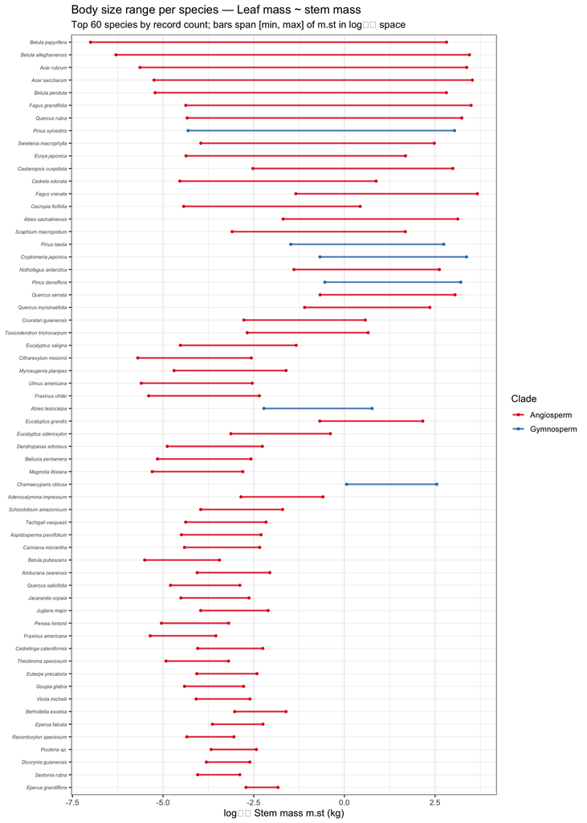

```r
plot_size_range(r5, co5)
```

## 6.3 Scaling slope vs. size range

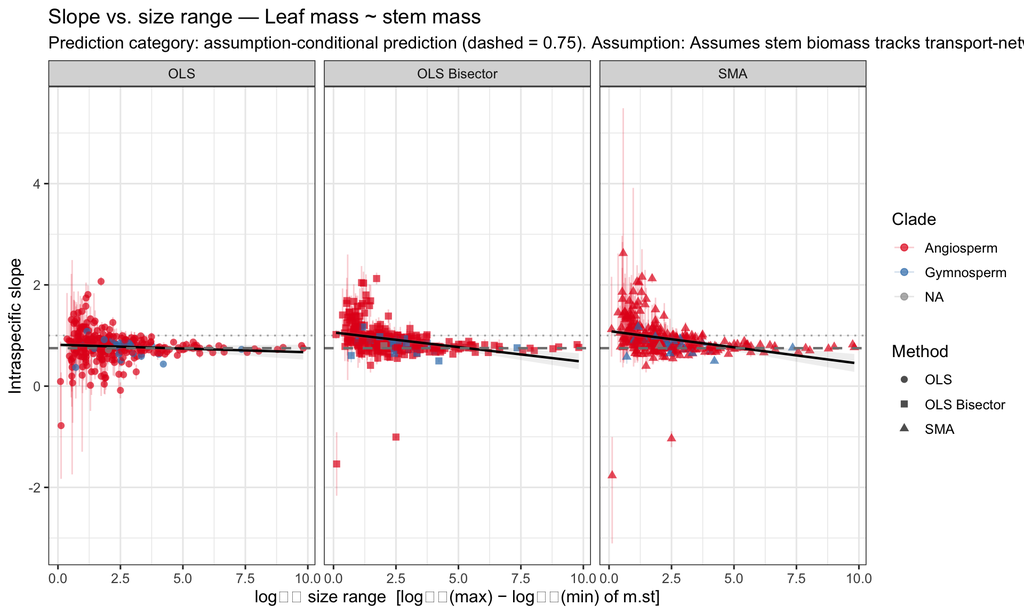

```r
plot_slope_vs_range(r5, co5)
```

## 6.4 Slope distributions

```r
slope_distribution_stats(
  r5,
  "Leaf mass ~ stem mass: slope distribution summary statistics"
)
```

Leaf mass ~ stem mass: slope distribution summary statistics

| Method | N | Mean slope | Median slope | Mean 95% CI lo | Mean 95% CI hi |
| --- | --- | --- | --- | --- | --- |
| OLS | 288 | 0.781 | 0.776 | 0.748 | 0.814 |
| SMA | 288 | 0.933 | 0.884 | 0.892 | 0.975 |
| OLS Bisector | 288 | 0.921 | 0.886 | 0.884 | 0.958 |

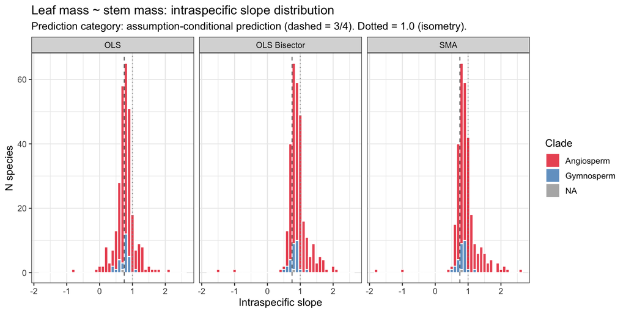

```r
if (nrow(r5) == 0) {
  ggplot() +
    theme_void() +
    labs(title = "Leaf mass ~ stem mass: no qualifying species for slope distribution")
} else {
  r5_long <- r5 %>%
    pivot_longer(cols = c(ols_slope, sma_slope, bis_slope),
                 names_to = "method", values_to = "slope") %>%
    mutate(method = recode(method, ols_slope = "OLS", sma_slope = "SMA",
                           bis_slope = "OLS Bisector")) %>%
    filter(!is.na(slope), is.finite(slope))

  if (nrow(r5_long) == 0) {
    ggplot() +
      theme_void() +
      labs(title = "Leaf mass ~ stem mass: no finite slope values available")
  } else {
    ggplot(r5_long, aes(x = slope, fill = clade)) +
      geom_histogram(binwidth = 0.1, colour = "white", alpha = 0.75, position = "stack") +
      geom_vline(xintercept = 0.75, linetype = "dashed", colour = "grey40") +
      geom_vline(xintercept = 1.00, linetype = "dotted", colour = "grey60") +
      facet_wrap(~ method) +
      scale_fill_manual(values = c(Angiosperm="#e41a1c", Gymnosperm="#377eb8"),
                        na.value="grey60", name="Clade") +
       labs(x = "Intraspecific slope", y = "N species",
         title = "Leaf mass ~ stem mass: intraspecific slope distribution",
         subtitle = "Prediction category: assumption-conditional prediction (dashed = 3/4). Dotted = 1.0 (isometry).")
  }
}
```

# 7 Leaf area ~ Stem mass (`a.lf ~ m.st`)

```r
r6  <- results[["a.lf~m.st"]]
co6 <- combos[[6]]
cat("Species qualifying (≥", MIN_N, "records):", nrow(r6), "\n")
```

```
## Species qualifying (≥ 10 records): 240
```

```r
cat("Median OLS slope:", round(median(r6$ols_slope, na.rm=TRUE), 3), "\n")
```

```
## Median OLS slope: 0.72
```

```r
cat("Median SMA slope:", round(median(r6$sma_slope, na.rm=TRUE), 3), "\n")
```

```
## Median SMA slope: 0.827
```

```r
cat("Median Bisector slope:", round(median(r6$bis_slope, na.rm=TRUE), 3), "\n")
```

```
## Median Bisector slope: 0.83
```

## 7.1 Per-species slopes table

```r
table_slopes(r6, paste0("Leaf area ~ stem mass: per-species OLS, SMA, and OLS Bisector slopes (≥ ",
                         MIN_N, " records per species, sorted by N)"))
```

Leaf area ~ stem mass: per-species OLS, SMA, and OLS Bisector slopes (≥ 10 records per species, sorted by N)

| Species | Family | Clade | N | OLS slope | OLS 95% lo | OLS 95% hi | SMA slope | SMA 95% lo | SMA 95% hi | Bisector slope | Bis 95% lo | Bis 95% hi | R² | log₁₀ size range |
| --- | --- | --- | --- | --- | --- | --- | --- | --- | --- | --- | --- | --- | --- | --- |
| *Betula alleghaniensis* | Betulaceae | Angiosperm | 391 | 0.813 | 0.794 | 0.833 | 0.836 | 0.817 | 0.856 | 0.836 | 0.812 | 0.860 | 0.946 | 6.240 |
| *Acer saccharum* | Aceraceae | Angiosperm | 347 | 0.696 | 0.673 | 0.719 | 0.729 | 0.706 | 0.752 | 0.729 | 0.710 | 0.749 | 0.911 | 4.843 |
| *Eucalyptus saligna* | Myrtaceae | Angiosperm | 276 | 0.784 | 0.761 | 0.807 | 0.807 | 0.785 | 0.831 | 0.807 | 0.780 | 0.835 | 0.943 | 3.192 |
| *Pinus taeda* | Pinaceae | Gymnosperm | 228 | 0.322 | 0.269 | 0.374 | 0.516 | 0.466 | 0.572 | 0.549 | 0.507 | 0.590 | 0.388 | 3.798 |
| *Fagus grandifolia* | Fagaceae | Angiosperm | 222 | 0.549 | 0.479 | 0.619 | 0.761 | 0.694 | 0.834 | 0.771 | 0.691 | 0.851 | 0.522 | 2.357 |
| *Eucalyptus sideroxylon* | Myrtaceae | Angiosperm | 184 | 0.673 | 0.635 | 0.712 | 0.722 | 0.685 | 0.761 | 0.723 | 0.678 | 0.768 | 0.870 | 2.745 |
| *Juglans major* | Juglandaceae | Angiosperm | 184 | 0.096 | -0.124 | 0.316 | 1.509 | 1.304 | 1.745 | 1.055 | 0.927 | 1.184 | 0.004 | 1.859 |
| *Persea hintonii* | Lauraceae | Angiosperm | 182 | 0.061 | -0.144 | 0.265 | 1.392 | 1.202 | 1.611 | 1.030 | 0.905 | 1.154 | 0.002 | 1.854 |
| *Magnolia iltisiana* | Magnoliaceae | Angiosperm | 171 | -0.068 | -0.230 | 0.095 | -1.072 | -1.247 | -0.922 | -1.009 | -1.038 | -0.980 | 0.004 | 2.500 |
| *Betula pendula* | Betulaceae | Angiosperm | 170 | 0.717 | 0.636 | 0.797 | 0.889 | 0.812 | 0.973 | 0.891 | 0.804 | 0.979 | 0.650 | 2.029 |
| *Cecropia ficifolia* | Cecropiaceae | Angiosperm | 169 | 0.648 | 0.603 | 0.693 | 0.711 | 0.668 | 0.758 | 0.712 | 0.660 | 0.765 | 0.830 | 4.867 |
| *Toxicodendron trichocarpum* | Anacardiaceae | Angiosperm | 167 | 0.614 | 0.566 | 0.662 | 0.688 | 0.642 | 0.737 | 0.690 | 0.634 | 0.746 | 0.797 | 3.334 |
| *Citharexylum mocinnii* | Verbenaceae | Angiosperm | 164 | 0.269 | 0.115 | 0.423 | 1.029 | 0.886 | 1.194 | 1.014 | 0.958 | 1.070 | 0.069 | 3.132 |
| *Betula pubescens* | Betulaceae | Angiosperm | 156 | 0.869 | 0.801 | 0.938 | 0.970 | 0.904 | 1.041 | 0.970 | 0.897 | 1.044 | 0.803 | 2.064 |
| *Dendropanax arboreus* | Araliaceae | Angiosperm | 150 | 0.202 | 0.103 | 0.302 | 0.644 | 0.552 | 0.751 | 0.773 | 0.694 | 0.853 | 0.099 | 2.623 |
| *Eucalyptus grandis* | Myrtaceae | Angiosperm | 144 | 0.312 | 0.241 | 0.384 | 0.533 | 0.466 | 0.609 | 0.573 | 0.502 | 0.643 | 0.344 | 2.840 |
| *Fraxinus uhdei* | Oleaceae | Angiosperm | 142 | 0.490 | 0.339 | 0.641 | 1.029 | 0.889 | 1.191 | 1.023 | 0.925 | 1.120 | 0.227 | 3.054 |
| *Theobroma speciosum* | Sterculiaceae | Angiosperm | 119 | 1.908 | 1.813 | 2.004 | 1.978 | 1.885 | 2.076 | 1.978 | 1.861 | 2.094 | 0.931 | 1.724 |
| *Aspidosperma parvifolium* | Apocynaceae | Angiosperm | 118 | 1.016 | 0.903 | 1.129 | 1.188 | 1.080 | 1.306 | 1.185 | 1.013 | 1.358 | 0.732 | 2.196 |
| *Virola michelii* | Myristicaceae | Angiosperm | 118 | 1.266 | 1.054 | 1.479 | 1.715 | 1.515 | 1.940 | 1.677 | 1.402 | 1.953 | 0.545 | 1.485 |
| *Cariniana micrantha* | Lecythidaceae | Angiosperm | 117 | 0.969 | 0.927 | 1.011 | 0.996 | 0.955 | 1.039 | 0.996 | 0.957 | 1.035 | 0.948 | 2.072 |
| *Tachigali vasquezii* | Fabaceae | Angiosperm | 117 | 0.862 | 0.817 | 0.907 | 0.895 | 0.852 | 0.941 | 0.895 | 0.867 | 0.924 | 0.927 | 2.216 |
| *Eperua falcata* | Caesalpiniaceae | Angiosperm | 115 | 0.888 | 0.799 | 0.976 | 1.008 | 0.923 | 1.100 | 1.007 | 0.936 | 1.079 | 0.776 | 1.393 |
| *Cedrela odorata* | Meliaceae | Angiosperm | 114 | 0.719 | 0.675 | 0.763 | 0.756 | 0.714 | 0.802 | 0.757 | 0.695 | 0.819 | 0.903 | 5.412 |
| *Pouteria sp.* | Sapotaceae | Angiosperm | 114 | 0.970 | 0.719 | 1.220 | 1.651 | 1.420 | 1.921 | 1.556 | 1.307 | 1.805 | 0.345 | 1.246 |
| *Ulmus americana* | Ulmaceae | Angiosperm | 114 | 0.825 | 0.722 | 0.929 | 0.994 | 0.896 | 1.103 | 0.994 | 0.881 | 1.107 | 0.689 | 3.060 |
| *Euterpe precatoria* | Aracaceae | Angiosperm | 113 | 0.878 | 0.809 | 0.948 | 0.952 | 0.886 | 1.024 | 0.952 | 0.888 | 1.017 | 0.851 | 1.659 |
| *Swietenia macrophylla* | Meliaceae | Angiosperm | 113 | 0.808 | 0.753 | 0.862 | 0.858 | 0.805 | 0.914 | 0.858 | 0.808 | 0.908 | 0.886 | 1.828 |
| *Dicorynia guianensis* | Caesalpiniaceae | Angiosperm | 111 | 1.780 | 1.589 | 1.972 | 2.046 | 1.863 | 2.246 | 2.034 | 1.793 | 2.274 | 0.757 | 1.199 |
| *Recordoxylon speciosum* | Caesalpiniaceae | Angiosperm | 111 | 1.249 | 1.008 | 1.490 | 1.782 | 1.557 | 2.039 | 1.727 | 1.357 | 2.096 | 0.492 | 1.299 |

[output cut: 210 more lines]

## 7.2 Body size range per species

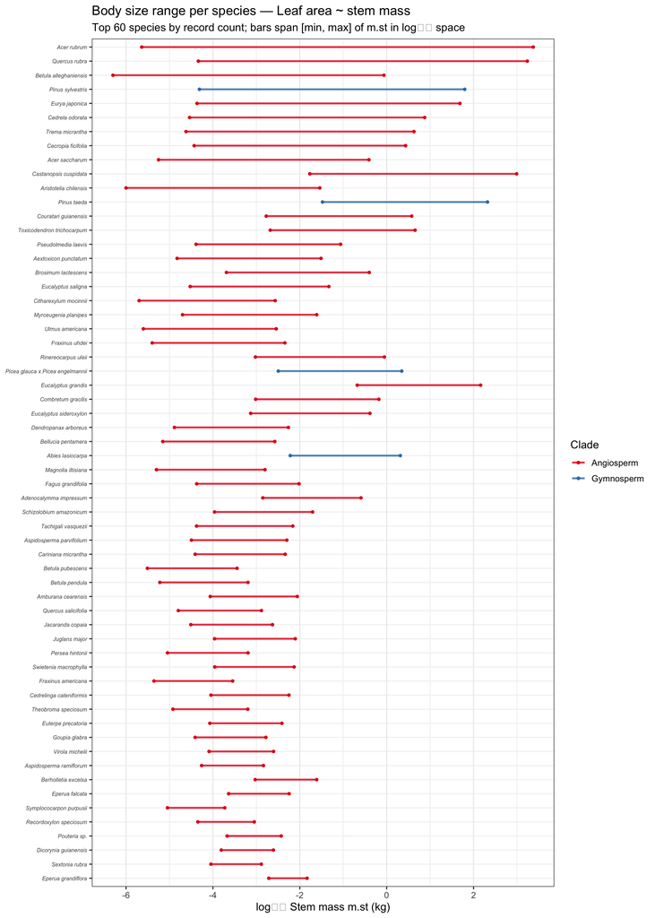

```r
plot_size_range(r6, co6)
```

## 7.3 Scaling slope vs. size range

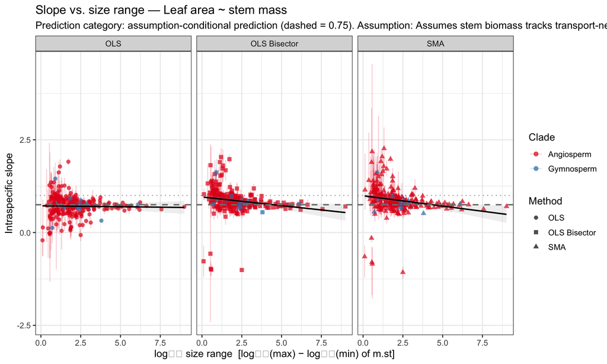

```r
plot_slope_vs_range(r6, co6)
```

## 7.4 Slope distributions

```r
slope_distribution_stats(
  r6,
  "Leaf area ~ stem mass: slope distribution summary statistics"
)
```

Leaf area ~ stem mass: slope distribution summary statistics

| Method | N | Mean slope | Median slope | Mean 95% CI lo | Mean 95% CI hi |
| --- | --- | --- | --- | --- | --- |
| OLS | 240 | 0.710 | 0.720 | 0.674 | 0.746 |
| SMA | 240 | 0.871 | 0.827 | 0.823 | 0.919 |
| OLS Bisector | 240 | 0.857 | 0.830 | 0.811 | 0.904 |

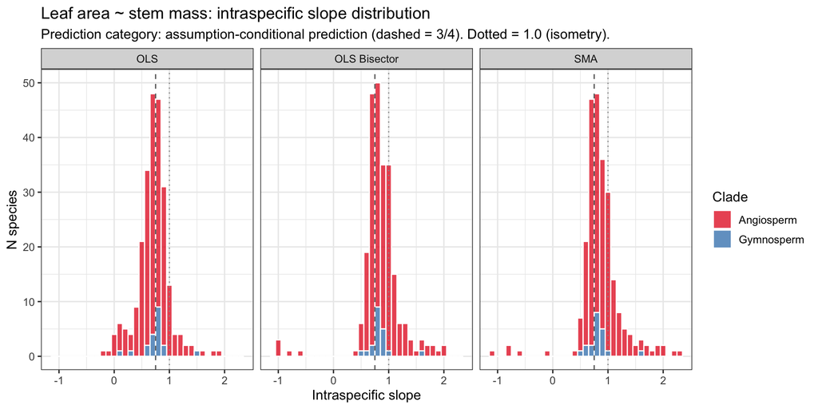

```r
if (nrow(r6) == 0) {
  ggplot() +
    theme_void() +
    labs(title = "Leaf area ~ stem mass: no qualifying species for slope distribution")
} else {
  r6_long <- r6 %>%
    pivot_longer(cols = c(ols_slope, sma_slope, bis_slope),
                 names_to = "method", values_to = "slope") %>%
    mutate(method = recode(method, ols_slope = "OLS", sma_slope = "SMA",
                           bis_slope = "OLS Bisector")) %>%
    filter(!is.na(slope), is.finite(slope))

  if (nrow(r6_long) == 0) {
    ggplot() +
      theme_void() +
      labs(title = "Leaf area ~ stem mass: no finite slope values available")
  } else {
    ggplot(r6_long, aes(x = slope, fill = clade)) +
      geom_histogram(binwidth = 0.1, colour = "white", alpha = 0.75, position = "stack") +
      geom_vline(xintercept = 0.75, linetype = "dashed", colour = "grey40") +
      geom_vline(xintercept = 1.00, linetype = "dotted", colour = "grey60") +
      facet_wrap(~ method) +
      scale_fill_manual(values = c(Angiosperm="#e41a1c", Gymnosperm="#377eb8"),
                        na.value="grey60", name="Clade") +
       labs(x = "Intraspecific slope", y = "N species",
         title = "Leaf area ~ stem mass: intraspecific slope distribution",
         subtitle = "Prediction category: assumption-conditional prediction (dashed = 3/4). Dotted = 1.0 (isometry).")
  }
}
```

# 8 Cross-combination summary

## 8.1 Median slopes and spread across all six relationships

```r
all_res <- bind_rows(
  lapply(seq_along(combos), function(i) {
    results[[i]] %>%
      mutate(combo     = names(results)[i],
             response  = combos[[i]]$y,
             predictor = combos[[i]]$x,
             wbe_ref   = combos[[i]]$wbe_ref)
  })
)

cross_sum <- all_res %>%
  group_by(combo) %>%
  summarise(
    n_species        = n(),
    wbe_pred         = ifelse(is.na(wbe_ref[1]), "none", as.character(wbe_ref[1])),
    med_ols          = round(median(ols_slope, na.rm = TRUE), 3),
    iqr_ols          = round(IQR(ols_slope, na.rm = TRUE), 3),
    pct_ols_lt_wbe   = round(mean(ols_slope < ifelse(is.na(wbe_ref[1]), Inf, wbe_ref[1]),
                                  na.rm = TRUE) * 100, 1),
    pct_ols_gt_iso   = round(mean(ols_slope > 1.00, na.rm = TRUE) * 100, 1),
    med_sma          = round(median(sma_slope, na.rm = TRUE), 3),
    iqr_sma          = round(IQR(sma_slope, na.rm = TRUE), 3),
    med_bis          = round(median(bis_slope, na.rm = TRUE), 3),
    iqr_bis          = round(IQR(bis_slope, na.rm = TRUE), 3),
    med_r2           = round(median(r2, na.rm = TRUE), 3),
    med_range        = round(median(log_x_range, na.rm = TRUE), 3),
    .groups = "drop"
  )

kable(cross_sum %>%
    select(combo, wbe_pred, n_species,
       med_ols, iqr_ols,
       pct_ols_lt_wbe, pct_ols_gt_iso,
       med_sma, iqr_sma,
       med_bis, iqr_bis,
       med_r2, med_range),
      col.names = c("Combination", "WBE exponent", "N species",
                    "Median OLS slope", "IQR (OLS)",
                    "% OLS < WBE", "% OLS > 1.0",
                    "Median SMA slope", "IQR (SMA)",
                    "Median Bisector slope", "IQR (Bis)",
                    "Median R²", "Median log₁₀ range"),
      caption = paste0("Cross-combination summary of intraspecific slopes (≥ ", MIN_N,
               " records/species). Prediction categories: numeric 2.0 for diameter predictors,",
               " numeric 3/4 for total biomass, and assumption-conditional 3/4 for stem mass."))
```

Cross-combination summary of intraspecific slopes (≥ 10 records/species). Prediction categories: numeric 2.0 for diameter predictors, numeric 3/4 for total biomass, and assumption-conditional 3/4 for stem mass.

| Combination | WBE exponent | N species | Median OLS slope | IQR (OLS) | % OLS < WBE | % OLS > 1.0 | Median SMA slope | IQR (SMA) | Median Bisector slope | IQR (Bis) | Median R² | Median log₁₀ range |
| --- | --- | --- | --- | --- | --- | --- | --- | --- | --- | --- | --- | --- |
| a.lf~d.ba | 2 | 182 | 2.005 | 0.781 | 49.5 | 89.0 | 2.382 | 0.837 | 2.295 | 0.815 | 0.734 | 0.567 |
| a.lf~m.st | 0.75 | 240 | 0.720 | 0.255 | 55.4 | 7.9 | 0.827 | 0.280 | 0.830 | 0.274 | 0.804 | 1.869 |
| a.lf~m.to | 0.75 | 156 | 0.881 | 0.224 | 20.5 | 25.0 | 0.947 | 0.256 | 0.948 | 0.242 | 0.871 | 1.475 |
| m.lf~d.ba | 2 | 204 | 2.112 | 0.773 | 40.7 | 93.6 | 2.485 | 0.817 | 2.433 | 0.807 | 0.791 | 0.648 |
| m.lf~m.st | 0.75 | 288 | 0.776 | 0.242 | 42.7 | 12.5 | 0.884 | 0.243 | 0.886 | 0.238 | 0.870 | 1.952 |
| m.lf~m.to | 0.75 | 171 | 0.959 | 0.213 | 7.6 | 42.1 | 1.007 | 0.240 | 1.007 | 0.240 | 0.927 | 1.570 |

## 8.2 OLS vs. SMA slope comparison — all combinations

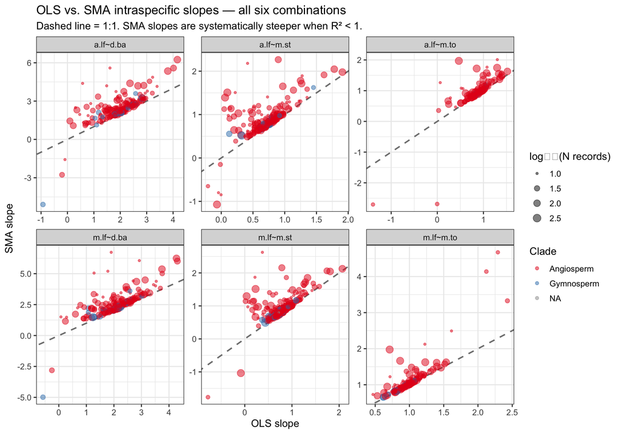

```r
all_res %>%
  filter(!is.na(ols_slope), !is.na(sma_slope)) %>%
  ggplot(aes(x = ols_slope, y = sma_slope, colour = clade)) +
  geom_abline(slope = 1, intercept = 0, linetype = "dashed",
              colour = "grey50", linewidth = 0.8) +
  geom_point(aes(size = log10(n)), alpha = 0.5) +
  scale_colour_manual(values = c(Angiosperm = "#e41a1c", Gymnosperm = "#377eb8"),
                      na.value = "grey60", name = "Clade") +
  scale_size_continuous(range = c(1, 4), name = "log₁₀(N records)") +
  facet_wrap(~ combo, scales = "free", ncol = 3) +
  labs(
    x = "OLS slope", y = "SMA slope",
    title = "OLS vs. SMA intraspecific slopes — all six combinations",
    subtitle = "Dashed line = 1:1. SMA slopes are systematically steeper when R² < 1."
  )
```

## 8.3 Size range vs. R² — all combinations

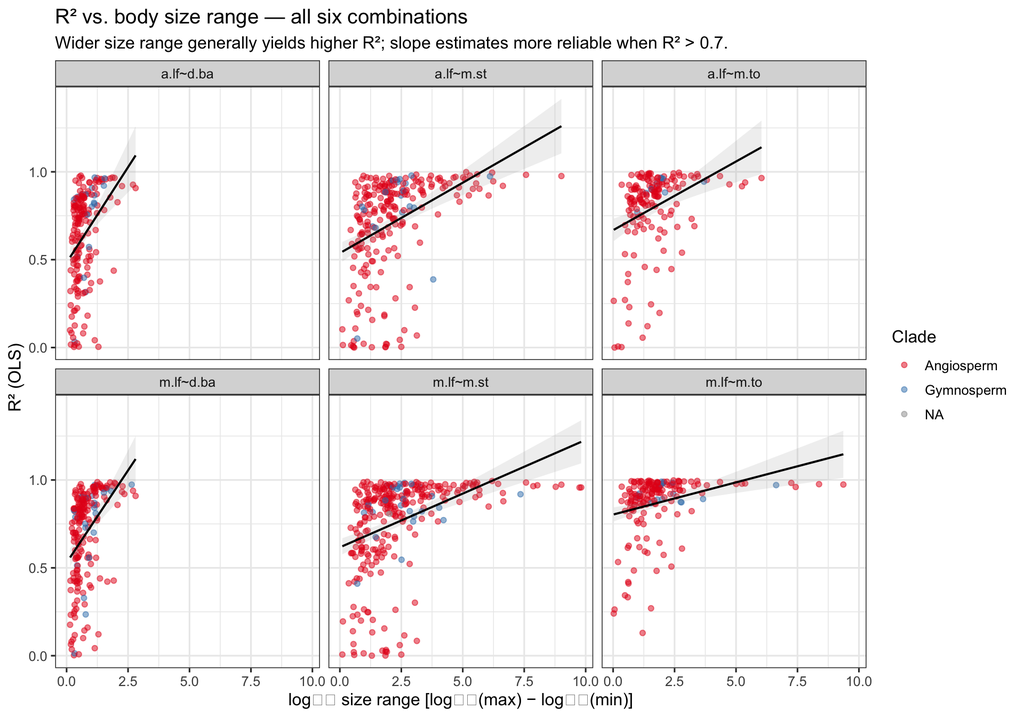

```r
all_res %>%
  filter(!is.na(r2)) %>%
  ggplot(aes(x = log_x_range, y = r2, colour = clade)) +
  geom_point(alpha = 0.5, size = 1.5) +
  geom_smooth(aes(group = 1), method = "lm", colour = "black",
              se = TRUE, linewidth = 0.7, alpha = 0.15) +
  scale_colour_manual(values = c(Angiosperm = "#e41a1c", Gymnosperm = "#377eb8"),
                      na.value = "grey60", name = "Clade") +
  facet_wrap(~ combo, ncol = 3) +
  labs(
    x = "log₁₀ size range [log₁₀(max) − log₁₀(min)]",
    y = "R² (OLS)",
    title = "R² vs. body size range — all six combinations",
    subtitle = "Wider size range generally yields higher R²; slope estimates more reliable when R² > 0.7."
  )
```